```python
import pandas as pd
import sklearn
import numpy as np
import matplotlib.pyplot as plt

df=pd.read_csv('Kevin_Hillstrom_MineThatData_E-MailAnalytics_DataMiningChallenge_2008.03.20.csv')
```

# Feature importance - Classification on dataset for uplift

**Autor: Paulina Tomaszewska**

*dla lepszej możliwości porównywania wykresów feature importance wszędzie zastosowano taką samą kolejność nazw kolumn na osi pionowej (alternatywnie można było posortować wartości malejąco)*

Historical customer attributes at your disposal include:

- Recency: Months since last purchase.
- History_Segment: Categorization of dollars spent in the past year.
- History: Actual dollar value spent in the past year.
- Mens: 1/0 indicator, 1 = customer purchased Mens merchandise in the past year.
- Womens: 1/0 indicator, 1 = customer purchased Womens merchandise in the past year.
- Zip_Code: Classifies zip code as Urban, Suburban, or Rural.
- Newbie: 1/0 indicator, 1 = New customer in the past twelve months.
- Channel: Describes the channels the customer purchased from in the past year.

Another variable describes the e-mail campaign the customer received:

- Segment (Mens E-Mail, Womens E-Mail, No E-Mail)

Finally, we have a series of variables describing activity in the two weeks following delivery of the e-mail campaign:

- Visit: 1/0 indicator, 1 = Customer visited website in the following two weeks.
- Conversion: 1/0 indicator, 1 = Customer purchased merchandise in the following two weeks.
- Spend: Actual dollars spent in the following two weeks.

```python
df.head()
```

|  | recency | history_segment | history | mens | womens | zip_code | newbie | channel | segment | visit | conversion | spend |
| --- | --- | --- | --- | --- | --- | --- | --- | --- | --- | --- | --- | --- |
| 0 | 10 | 2) $100 - $200 | 142.44 | 1 | 0 | Surburban | 0 | Phone | Womens E-Mail | 0 | 0 | 0.0 |
| 1 | 6 | 3) $200 - $350 | 329.08 | 1 | 1 | Rural | 1 | Web | No E-Mail | 0 | 0 | 0.0 |
| 2 | 7 | 2) $100 - $200 | 180.65 | 0 | 1 | Surburban | 1 | Web | Womens E-Mail | 0 | 0 | 0.0 |
| 3 | 9 | 5) $500 - $750 | 675.83 | 1 | 0 | Rural | 1 | Web | Mens E-Mail | 0 | 0 | 0.0 |
| 4 | 2 | 1) $0 - $100 | 45.34 | 1 | 0 | Urban | 0 | Web | Womens E-Mail | 0 | 0 | 0.0 |

## Feature Engineering

W ramach preprocessingu danych przygotowałam trzy warianty:

- zmienne kategoryczne (Zip_code i Channel) zamieniłam na One-hot
- zmienne kategoryczne (Zip_code i Channel) zamieniłam na Target encoding
- zmienne kategoryczne (Zip_code i Channel) zamieniłam na One-hot, natomiiast zmienną ciągłą history poddałam transformacji Boxcox

```python
df.drop(['history_segment', "conversion", "spend"], axis=1, inplace=True)
df.segment= df.segment.map({'Womens E-Mail': 1, 'Mens E-Mail': 1, 'No E-Mail': 0})

import category_encoders as ce
cat_cols=['zip_code', 'channel']

data=df.copy()
X=df.drop('visit', axis=1)
y=data_ohe.visit

from sklearn.model_selection import train_test_split
X_train, X_test, y_train, y_test = train_test_split( X,y, test_size=0.2, stratify=y, random_state=42)

#one-hot
ce_one_hot = ce.OneHotEncoder(cols = cat_cols, use_cat_names=True)
X_train_ohe=ce_one_hot.fit_transform(X_train)
X_test_ohe=ce_one_hot.transform(X_test)

#target encoding
from category_encoders import target_encoder
X_train_te=X_train.copy()
X_test_te=X_test.copy()
for i in cat_cols:
    te=target_encoder.TargetEncoder()
    X_train_te.loc [:,i] = te.fit_transform(X_train_te.loc[:,i], y_train)
    X_test_te.loc [:,i] = te.transform(X_test_te[i])

#box-cox
from scipy import stats
X_train_boxcox=X_train_ohe.copy()
X_test_boxcox=X_test_ohe.copy()

X_train_boxcox.history,fitted_lambda = stats.boxcox(X_train_ohe.history)
X_test_boxcox.history = stats.boxcox(X_test_ohe.history, fitted_lambda)
```

# Functions

```python
def train_model (model, X_train, y_train):
    model.fit(X_train, y_train)
    return model

def plot_permutation_importance (score_decreases,col_names, title):
    feature_importances = np.mean(score_decreases, axis=0)
    plt.figure(figsize=(15,10))
    plt.barh(col_names,feature_importances)
    plt.title(title)
    plt.show()
```

## Gradient Boosting

```python
from sklearn.ensemble import GradientBoostingClassifier

model_gb=GradientBoostingClassifier(n_estimators=100)
```

### Ohe-hot encoding

```python
model_gb_ohe=train_model(model_gb, X_train_ohe, y_train)
```

W przypadku modelu drzewiastego postanowiłam oprócz PermutationImportance zbadać także zachowanie feature importance dedykowanemu temu typowi modeli.

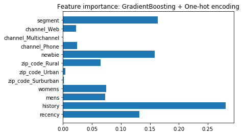

```python
plt.barh(X_train_ohe.columns, model_gb_ohe.feature_importances_)
plt.title('Feature importance: GradientBoosting + One-hot encoding')
```

Wniosek: Największe feature importance mają zmienne history, segment, newbie i recency. Wydaje się to zgodne z logiką, że decyzja modelu czy klient odwiedzi w ciągu 2 tygodni stronę internetową w głównej mierze zależy od tego ile pieniędzy wydał na nasze produkty w poprzednim roku, a także czy otrzymał materiały promocyjne (zmienna segment).

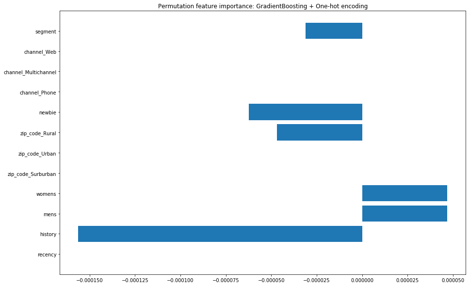

```python
def score (X,y):
    y_pred = model_gb_ohe.predict(X)
    return accuracy_score(y, y_pred)

base_score, score_decreases = get_score_importances(score, X_test_ohe.values, y_test.values)

plot_permutation_importance(score_decreases, X_test_ohe.columns,'Permutation feature importance: GradientBoosting + One-hot encoding')
```

Przeanalizowano także Permutation Feature Importance. Pierwszą różnicą w stosunku do powyższego wykresu jest to, że w tym przypadku feature importance ma wartość ujemną co oznacza, że po dokonaniu permutacji danej kolumny jakość klasyfikatora była lepsza. Dotyczyło to zmiennych segment, newbie, zip_code_Rural i history. Jedynymi zmiennymi, które miały dodatnie feature importance były zmienna womens i mens. Są też zmienne takie jak np. recency, których spermutowanie nie wpłynęło na jakość klasyfikacji. Dodatkowo zaobserwowano, że wartości na osi poziomej są znacznie mniejsze niż na pierwszym wykresie.

### Target encoding

```python
model_gb_te=train_model(model_gb, X_train_te, y_train)
```

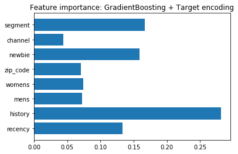

```python
plt.barh(X_train_te.columns, model_gb_te.feature_importances_)
plt.title('Feature importance: GradientBoosting + Target encoding')
```

Wniosek: Największe feature importance mają zmienne history, segment, newbie i recency (co pokrywa się z przypadkiem gdy zmienne kategoryczne były zakodowane z użyciem One-hot encoding a zmienna history nie została poddana transformacji Boxcox).

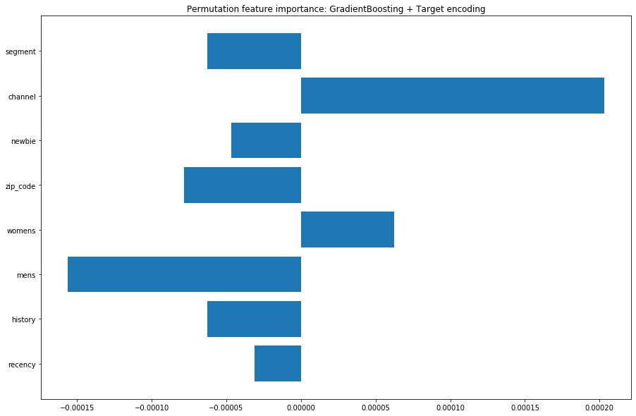

```python
def score (X,y):
    y_pred = model_gb_te.predict(X)
    return accuracy_score(y, y_pred)

base_score, score_decreases = get_score_importances(score, X_test_te.values, y_test.values)

plot_permutation_importance(score_decreases, X_test_te.columns,'Permutation feature importance: GradientBoosting + Target encoding')
```

W przypadku tego wykresu zaobserwowano znaczną różnicę w jego kształcie w porównaniu do wykresu gdzie przedstawiono wykres nauczony na danych z One-hot encoding. Tym razem ujemną wartość permutation feature importance mają wszystkie zmienne z wyjątkiem channel i womens. Gdy zmienna channel była zakodowano jako one-hot wówczas miała zerową wartość feature importance dla każdej kolumny odpowiadającej unikalnej wartości zmiennej. Tymczasem gdy użyto do zakodowania target encoding zmienna bardzo zyskała na znaczeniu.

### Boxcox

```python
model_gb_boxcox=train_model(model_gb, X_train_boxcox, y_train)
```

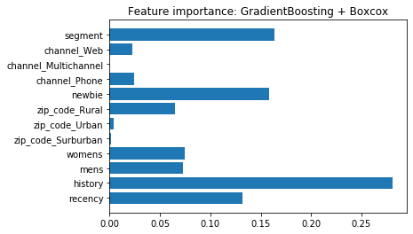

```python
plt.barh(X_train_boxcox.columns, model_gb_boxcox.feature_importances_)
plt.title('Feature importance: GradientBoosting + Boxcox')
```

Wniosek: Największe feature importance mają zmienne history, segment, newbie i recency. Wydaje się to zgodne z logiką, że decyzja modelu czy klient odwiedzi w ciągu 2 tygodni stronę internetową w głównej mierze zależy od tego ile pieniędzy wydał na nasze produkty w poprzednim roku, a także czy otrzymał materiały promocyjne (zmienna segment).

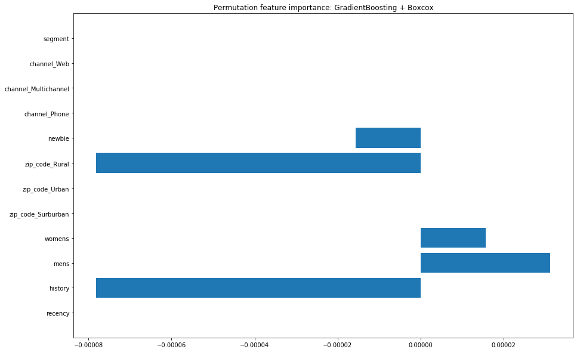

```python
def score (X,y):
    y_pred = model_gb_boxcox.predict(X)
    return accuracy_score(y, y_pred)

base_score, score_decreases = get_score_importances(score, X_test_boxcox.values, y_test.values)

plot_permutation_importance(score_decreases, X_test_boxcox.columns,'Permutation feature importance: GradientBoosting + Boxcox')
```

# Naive Bayes

```python
from sklearn.naive_bayes import BernoulliNB
from sklearn.pipeline import make_pipeline
from sklearn.preprocessing import MinMaxScaler

model_nb = make_pipeline(
    MinMaxScaler(),
    BernoulliNB(alpha=10.0, fit_prior=False)
)
```

## One-hot

```python
model_nb_ohe=train_model(model_nb, X_train_ohe, y_train)

def score (X,y):
    y_pred = model_nb_ohe.predict(X)
    return accuracy_score(y, y_pred)

base_score, score_decreases = get_score_importances(score, X_test_ohe.values, y_test.values)

plot_permutation_importance(score_decreases, X_test_ohe.columns,'Permutation feature importance: Naive Bayes + One-hot encoding')
```

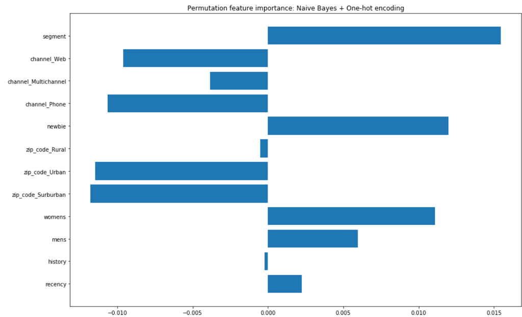

## Target encoding

```python
model_nb_te=train_model(model_nb, X_train_te, y_train)
```

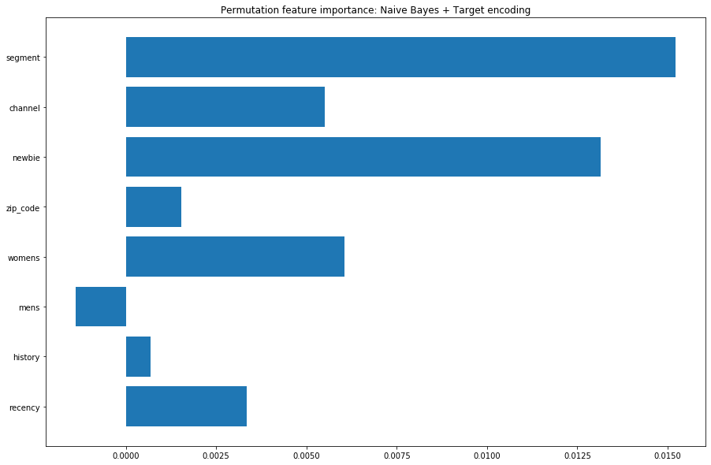

```python
def score (X,y):
    y_pred = model_nb_te.predict(X)
    return accuracy_score(y, y_pred)

base_score, score_decreases = get_score_importances(score, X_test_te.values, y_test.values)

plot_permutation_importance(score_decreases, X_test_te.columns,'Permutation feature importance: Naive Bayes + Target encoding')
```

W przypadku tego wykresu zaobserwowano znaczną różnicę w jego kształcie w porównaniu do analogicznego wykresu dla modelu GradientBoosting. W przypadku GradientBoosting wszystkie zmienne z wyjątkiem channel i womens miały ujemne feature importance, natomiast w przypadku Naive Bayes jedynie zmienna mens miała ujemną wartość. Dla modelu GradientBoosting największe feature importance miały zmienne channel i womens. Natomiast dla modelu Naive Bayes największe znaczenie o charakterze pozytywnym miała zmienna segment i newbie.

## Boxcox

```python
model_nb_boxcox=train_model(model_nb, X_train_boxcox, y_train)
```

```python
def score (X,y):
    y_pred = model_nb_boxcox.predict(X)
    return accuracy_score(y, y_pred)

base_score, score_decreases = get_score_importances(score, X_test_boxcox.values, y_test.values)

plot_permutation_importance(score_decreases, X_test_boxcox.columns,'Permutation feature importance: Naive Bayes + Boxcox')
```

[output not shown]

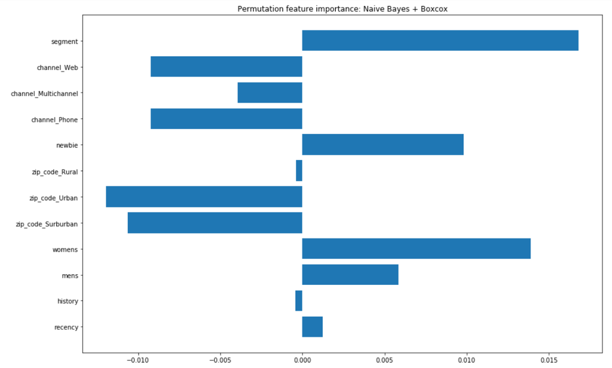

Wykres znacznie różni się kształtem w porównaniu do analogicznego wykresu dla modelu GradientBoosting. W przypadku modelu Gradient Boosting największe dodatnie feature importance miały zmienne mens i womens, natomiast w Naive Bayes jest to zmienna segment i womens.

# Podsumowanie